# Explore squid tag data

Julie and Whitney

10/10/2017

## Goal:

Let’s recreate this figure from [Stewart et al. 2014](http://www.sciencedirect.com/science/article/pii/S0967064512000860) in R instead of Matlab:

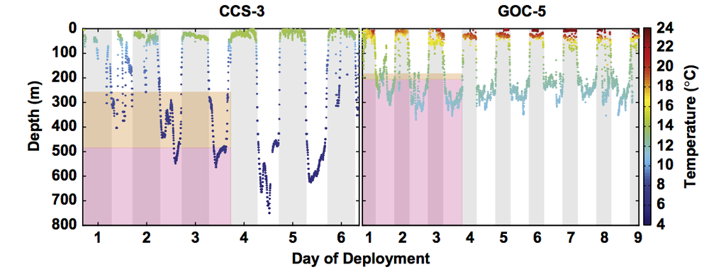

This means that we’re going to start of plotting Day v. Depth, with color as an overlay to represent temperature.

## Setup

Load appropriate libraries. `tidyverse` is a meta-package (see [tidyverse.org](https://www.tidyverse.org/)). It will load `dplyr` and `ggplot2`, which we will use a lot. We’ll also use `lubridate`.

```r
library(tidyverse)
library(lubridate)
```

## Read in Data

```r
d <- readr::read_csv('data/83052-Series.csv', skip = 3)

## little peek of first 6 rows (default)
head(d)
```

```
## # A tibble: 6 x 12
##   DeployID   Ptt Instr         Day     Time LocationQuality Latitude
##      <int> <int> <chr>       <chr>   <time>           <chr>    <chr>
## 1    83052 83052  Mk10 06-Nov-2009 00:28:45            <NA>     <NA>
## 2    83052 83052  Mk10 06-Nov-2009 00:30:00            <NA>     <NA>
## 3    83052 83052  Mk10 06-Nov-2009 00:31:15            <NA>     <NA>
## 4    83052 83052  Mk10 06-Nov-2009 00:32:30            <NA>     <NA>
## 5    83052 83052  Mk10 06-Nov-2009 00:33:45            <NA>     <NA>
## 6    83052 83052  Mk10 06-Nov-2009 00:35:00            <NA>     <NA>
## # ... with 5 more variables: Longitude <chr>, Depth <dbl>, DRange <dbl>,
## #   Temperature <dbl>, TRange <dbl>
```

```r
## little peek of last 10 rows
tail(d, 10)
```

```
## # A tibble: 10 x 12
##    DeployID   Ptt Instr         Day     Time LocationQuality Latitude
##       <int> <int> <chr>       <chr>   <time>           <chr>    <chr>
##  1    83052 83052  Mk10 13-Nov-2009 01:47:30               1   36.211
##  2    83052 83052  Mk10 13-Nov-2009 01:48:45               1   36.211
##  3    83052 83052  Mk10 13-Nov-2009 01:50:00               1   36.211
##  4    83052 83052  Mk10 13-Nov-2009 01:51:15               1   36.211
##  5    83052 83052  Mk10 13-Nov-2009 01:52:30               1   36.211
##  6    83052 83052  Mk10 13-Nov-2009 01:53:45               1   36.211
##  7    83052 83052  Mk10 13-Nov-2009 01:55:00               1   36.211
##  8    83052 83052  Mk10 13-Nov-2009 01:56:15               1   36.211
##  9    83052 83052  Mk10 13-Nov-2009 01:57:30               1   36.211
## 10    83052 83052  Mk10 13-Nov-2009 01:58:45               1   36.211
## # ... with 5 more variables: Longitude <chr>, Depth <dbl>, DRange <dbl>,
## #   Temperature <dbl>, TRange <dbl>
```

```r
## quick stats: summary
summary(d)
```

```
##     DeployID          Ptt           Instr               Day
##  Min.   :83052   Min.   :83052   Length:7945        Length:7945
##  1st Qu.:83052   1st Qu.:83052   Class :character   Class :character
##  Median :83052   Median :83052   Mode  :character   Mode  :character
##  Mean   :83052   Mean   :83052
##  3rd Qu.:83052   3rd Qu.:83052
##  Max.   :83052   Max.   :83052
##
##      Time          LocationQuality      Latitude
##  Length:7945       Length:7945        Length:7945
##  Class1:hms        Class :character   Class :character
##  Class2:difftime   Mode  :character   Mode  :character
##  Mode  :numeric
##
##
##
##   Longitude             Depth           DRange        Temperature
##  Length:7945        Min.   :  0.0   Min.   : 0.500   Min.   : 4.70
##  Class :character   1st Qu.:  7.5   1st Qu.: 0.500   1st Qu.: 7.50
##  Mode  :character   Median : 34.0   Median : 1.500   Median :13.50
##                     Mean   :167.4   Mean   : 3.685   Mean   :11.07
##                     3rd Qu.:344.0   3rd Qu.: 4.000   3rd Qu.:13.80
##                     Max.   :750.0   Max.   :30.000   Max.   :18.80
##                     NA's   :457     NA's   :457      NA's   :336
##      TRange
##  Min.   :0.0500
##  1st Qu.:0.0500
##  Median :0.0500
##  Mean   :0.0663
##  3rd Qu.:0.0500
##  Max.   :0.2500
##  NA's   :336
```

```r
## quick stats: structure
str(d)
```

```
## Classes 'tbl_df', 'tbl' and 'data.frame':    7945 obs. of  12 variables:
##  $ DeployID       : int  83052 83052 83052 83052 83052 83052 83052 83052 83052 83052 ...
##  $ Ptt            : int  83052 83052 83052 83052 83052 83052 83052 83052 83052 83052 ...
##  $ Instr          : chr  "Mk10" "Mk10" "Mk10" "Mk10" ...
##  $ Day            : chr  "06-Nov-2009" "06-Nov-2009" "06-Nov-2009" "06-Nov-2009" ...
##  $ Time           :Classes 'hms', 'difftime'  atomic [1:7945] 1725 1800 1875 1950 2025 ...
##   .. ..- attr(*, "units")= chr "secs"
##  $ LocationQuality: chr  NA NA NA NA ...
##  $ Latitude       : chr  NA NA NA NA ...
##  $ Longitude      : chr  NA NA NA NA ...
##  $ Depth          : num  NA NA NA NA NA NA NA NA NA NA ...
##  $ DRange         : num  NA NA NA NA NA NA NA NA NA NA ...
##  $ Temperature    : num  18.8 18.5 18.3 17.8 17.6 17.3 16.9 16.9 16.9 16.6 ...
##  $ TRange         : num  0.15 0.05 0.05 0.05 0.15 0.05 0.15 0.15 0.15 0.05 ...
##  - attr(*, "spec")=List of 2
##   ..$ cols   :List of 12
##   .. ..$ DeployID       : list()
##   .. .. ..- attr(*, "class")= chr  "collector_integer" "collector"
##   .. ..$ Ptt            : list()
##   .. .. ..- attr(*, "class")= chr  "collector_integer" "collector"
##   .. ..$ Instr          : list()
##   .. .. ..- attr(*, "class")= chr  "collector_character" "collector"
##   .. ..$ Day            : list()
##   .. .. ..- attr(*, "class")= chr  "collector_character" "collector"
##   .. ..$ Time           :List of 1
##   .. .. ..$ format: chr ""
##   .. .. ..- attr(*, "class")= chr  "collector_time" "collector"
##   .. ..$ LocationQuality: list()
##   .. .. ..- attr(*, "class")= chr  "collector_character" "collector"
##   .. ..$ Latitude       : list()
##   .. .. ..- attr(*, "class")= chr  "collector_character" "collector"
##   .. ..$ Longitude      : list()
##   .. .. ..- attr(*, "class")= chr  "collector_character" "collector"
##   .. ..$ Depth          : list()
##   .. .. ..- attr(*, "class")= chr  "collector_double" "collector"
##   .. ..$ DRange         : list()
##   .. .. ..- attr(*, "class")= chr  "collector_double" "collector"
##   .. ..$ Temperature    : list()
##   .. .. ..- attr(*, "class")= chr  "collector_double" "collector"
##   .. ..$ TRange         : list()
##   .. .. ..- attr(*, "class")= chr  "collector_double" "collector"
##   ..$ default: list()
##   .. ..- attr(*, "class")= chr  "collector_guess" "collector"
##   ..- attr(*, "class")= chr "col_spec"
```

## Plot something

Let’s just see where we are.

In RStudio, go to Help > Cheatsheets > Data Visualization with ggplot2. We can use the basic structure of ggplot to give it data and plot points. Let’s look at Day v. Depth.

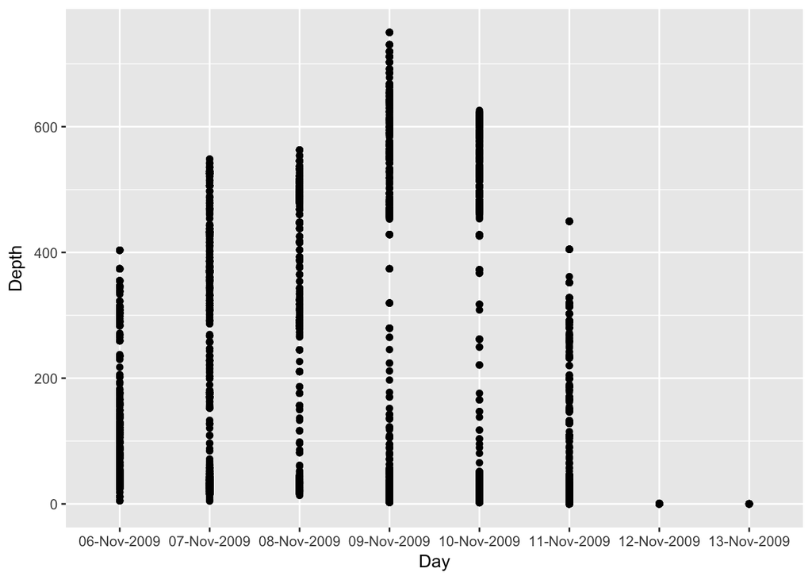

```r
ggplot(data = d) +
  geom_point(mapping = aes(x = Day, y = Depth))
```

OK so we’ve got some wrangling to do first!

We’ll need to:

- use functions from the `lubridate` package to combine Date and Time so that we can have a continuous plot
- color by temperature
- further tweeks.

How we’ll do it:

1. read [R for Data Science](http://r4ds.had.co.nz) Chapters 1-3 so that you’re familiar with ggplot2
2. read [OHI data science training](http://ohi-science.org/data-science-training/github-rstudio.html) Chapters 4-5 (and please tell me if it doesn’t make sense!! It’s a work in progress!)
- use the Cheatsheet and play around!

- Use dplyr to form a date-time by using the following function dmy_hms() or make_datetime(year, month, day, hour, second)
- I thought about trying this function but didnt end up using it `parse_datetime()`
- I dont think I needed to unclass the date field since its just a character string unclass(d$Date)

Making a new column of combined date and time and calling it dt:

```r
d$date_time = dmy_hms(paste(d$Day, d$Time))
dt <-d$date_time

## and here's how you'd do this with the tidyverse, within the d dataframe:
d <- d %>%
  mutate(DateTime = lubridate::dmy_hms(paste(Day, Time)))
```

## Now we can try to plot depth based on our combined day and time

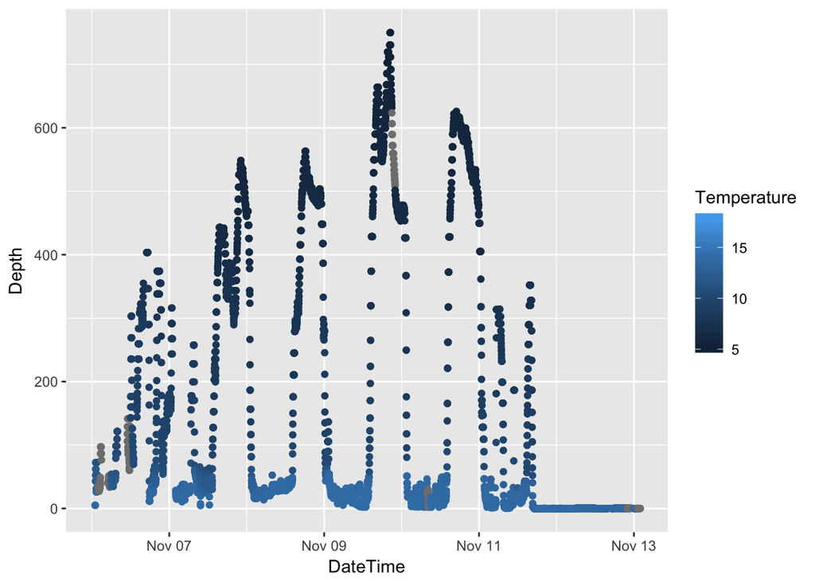

```r
ggplot(data = d) +
  geom_point(mapping = aes(x = DateTime, y = Depth, color = Temperature))
```

## Very cool!

Now we can flip the y axes (since it’s customary to make the top of the graph like the surface of the ocean)

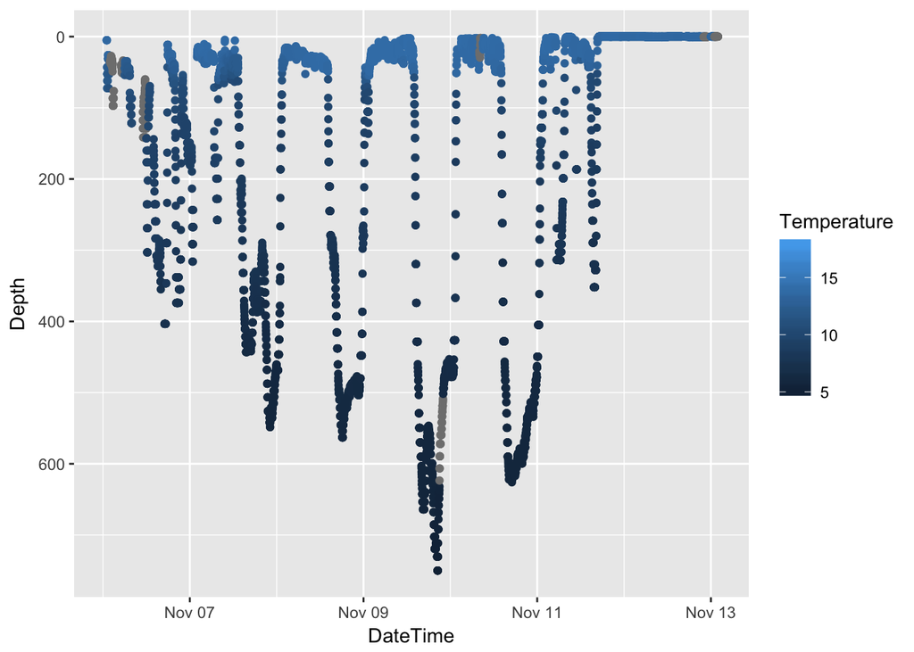

```r
ggplot(data = d) +
  geom_point(mapping = aes(x = DateTime, y = Depth, color = Temperature)) +
  scale_y_reverse()
```